## IE 360 Project Report

Group 7 - Alperen Köksal 2017402198 - Ekrem Barış Kuyucu 2017402264 - IE360 - Fall 2020

## Introduction

Electricity is used in every part of one’s life. Most of the technological devices need electricity in order to perform their functions. EPİAŞ (Enerji Piyasaları İşletme A.Ş.) is a company that provides hourly electricity consumption data of Turkey. In this project, we were expected to forecast the hourly electricity consumption of Turkey.

Historical electricity consumption data from 01 January 2017 were given in dataset. The provided data also included hourly temperature values for 7 different locations that may help to explain the behavior of electricity consumption time series.

Groups competed according to forecasts between 29th January and 12th February. Groups had to submit their consumption forecasts before 12:00 pm everyday. These forecasts are the forecasts for the day after submission. Last data which could be used for predictions were consumptions which occurred one day before the submission. Each day, groups were ranked according to their weighted mean absolute percentage error (WMAPE). Groups having the least WMAPE value become winner of the day and took 18 points. Overall ranking is determined with sorting groups by cumulative sum of daily ranking points.

As Group 7,we used autoregressive integrated moving average with regressors (ARIMAX) and naive forecast with lag 168.

## Related Literature

ARIMAX is a method that uses past observations in order to predict the future trend of data. This approach is used in general in the literature because of the simplicity. The ARIMAX model consists of four parts. These sections are Auto Regressive (AR), Integrated (I), Moving Average (MA), and External Variable (X).

There is a function called “auto.arima” that find the most suitable model for forecasting. It returns the best ARIMA model according to either AIC, AICc or BIC value. The function conducts a search over possible model within the order constraints provided.

WMAPE is a accuracy measure which uses actual and forecasted values. It is used in measuring the accuracy and comparing models.

## Approach

To get stationary data, some techniques are used such as outlier analysis and differencing. For this project, in order to forecast the consumption of the next day two methods are used: -ARIMAX -Naive forecast

## Outlier analysis

When the electricity data is plotted, there were seen that some points are very different from the usual pattern of the data. With the use of a basic linear regression model, these points are found and analyzed. If the reason of this behavior is known, a dummy variable is given to the outlier point in order to eliminate the effect of these outlier points in predictions. From basic knowledge it is thought that special holidays may be the reason of these outlier points, such as: New year’s eve, Ramadan fest, Kurban fest.

It is known that outliers with lower values are these special holidays. For the outliers with higher values reasons are harder to find. So a dummy variable is given for all values that are bigger than %99 of residuals of basic linear regression model.

## ARIMAX

When looking to the autocorrelation and partial autocorrelation functions of differenced values, there can be seen that there are strong correlations at some lags. So ARIMA model is decided to use in this project. Temperature and dummy variables for outliers also may help the model to explain the behavior of data so they are used with ARIMA model as an ARIMAX model. In order to use them, they are also weekly differed since model is created using weekly differenced electricity consumption values. With the help of these regressors and using “auto.arima” function, a model is fitted for each day with the lowest AIC value to use in forecasting.

With those models two days ahead forecasts are performed. Forecasted differenced values are transformed to electricity consumption values. WMAPE values are computed for forecasted values.

## Naive forecast

Naive forecast is done with using lag 168 values since previous week’s values have mostly a similar pattern as current week’s values. WMAPE values are computed for forecasted values.

## Results

Naive forecast and ARIMAX methods are used. Forecasted values are obtained by using these methods for the time period from 30-01-2021 to 13-02-2021. WMAPE values are calculated for both methods with the following formula.

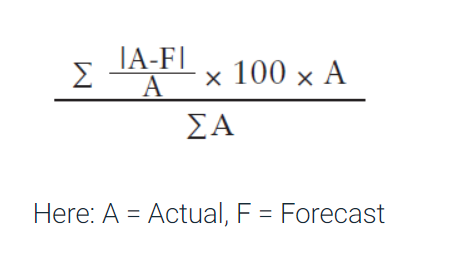

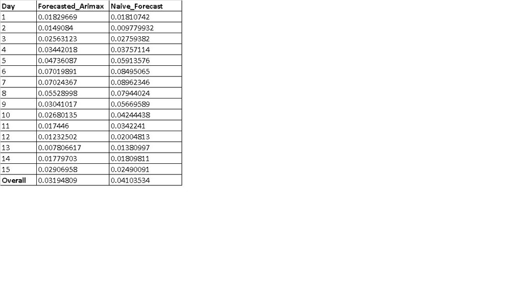

## Conclusion and Future Works

As mentioned above, there are several approaches to create a forecast and we used two methods to understand which method should be used for electricity consumption values in this project. We tested our approaches using test data set which created from existed time series for electricity consumption values and choose least WMAPE value.

In the first days of submission 24 hour differencing technique was used. However high WMAPE values which indicates that this approach is not good enough for accurate predictions are obtained. The reason of getting bad results using 24 hour differencing technique is that when two days ahead forecasting is done, error of first day is added to prediction of second day. So 168 hour differencing is decided to use.

To get more accurate predictions, further outlier analysis can be done, GAM(Generalized Additive Models), linear regression and simple moving average methods can be used instead of ARIMAX models.

## Code

https://bu-ie-360.github.io/fall20-bariskuyucu/files/project.html